# New York City Tree Census and Air Quality Analysis

Faisal Mushayt, Allen Qu, Zach Halvorson, Temma Pelletier

# Introduction

We plan on starting with a NY tree census dataset, and investigating any potential factors within that dataset. Additionally, we will investigate any potential relationships between our tree census dataset and a NYC air quality dataset we found.

**Data sets we plan to use:**

**NYC Tree Census:** This dataset includes a record for every tree in New York City and includes the tree’s location by borough and latitude/longitude, species by Latin name and common names, size, health, and issues with the tree’s roots, trunk, and branches: https://www.kaggle.com/nycparks/tree-census#new_york_tree_census_2015.csv

**NYC Air Quality:** This dataset contains information on New York City air quality surveillance data: https://data.cityofnewyork.us/Environment/Air-Quality/c3uy-2p5r

**Questions we want to investigate:** Tree density related to air quality indicators per borough. Tree specific questions - stump diameter vs. species, other physical qualities? Tree species resilience/survivability - how the tree condition changes from 1995 - 2015. Tree healthiness given air quality

**Unique visualizations we’d like to create** Interactive map of NY with trees plotted by latitude and longitude, colored by another factor(air quality, species of tree, etc.). Facet wraps or violin plots might also be interesting.

# Importing the data

First we import the tree census data into three separate variable for each year, and another variable for the species information

```
## # A tibble: 516,989 x 27
##    recordid address house_number street zip_original cb_original site
##       <int> <chr>   <chr>        <chr>         <int>       <int> <chr>
##  1   433600 73-031… 73-031       57 AV         11378         405 Front
##  2    48050 2434 H… 2434         HOFFM…        10458         106 Adja…
##  3   506340 33 MUL… 33           MULBE…        10314         502 Front
##  4   348044 79-037… 79-037       213 ST        11364         411 Front
##  5   354765 68-015… 68-015       172 ST        11365         408 Front
##  6   228644 30-023… 30-023       84 ST         11370         403 Front
##  7   154016 562 1 … 562          1 ST          11215         206 Front
##  8   499366 93 LIT… 93           LITTL…        10301         501 Side
##  9    51547 100 AL… 100          ALCOT…        10475         110 Front
## 10   377394 86-008… 86-008       RANGE…        11427         413 Front
## # ... with 516,979 more rows, and 20 more variables: species <chr>,
## #   diameter <int>, status <chr>, wires <chr>, sidewalk_condition <chr>,
## #   support_structure <chr>, borough <chr>, x <dbl>, y <dbl>,
## #   longitude <dbl>, latitude <dbl>, cb_new <int>, zip_new <int>,
## #   censustract_2010 <chr>, censusblock_2010 <chr>, nta_2010 <chr>,
## #   segmentid <int>, spc_common <chr>, spc_latin <chr>, location <chr>
```

## Longitude and Latitude clean up

Note how other than in the 2005 dataset, every entry describes a single tree. The issue with 2005 dataset is that “New York”, and the longitude and latitude appear on separate rows above and below the tree entry respectively. This section deals with that issue by combinging them to match the 1995 and 2015 format.

We check this by comparing the number of rows before and after wrangling, where 1,777,116 rows are in the intitial datase and 592,372 rows are in the final dataset. This is exactly 1/3 of the original dataset, which likely indicates that we cleaned the data correctly.

## Matching variable names

Next we will rename variables accross the datasets to ensure consistency and add a year variable to keep track of the records once we combine all of the datasets

Here we select the variables that we want to save in our subsetted variable

# Species Snapshot

Here we examine the rate at which particular types of trees occur in particular boroughs by first grouping the species of trees by their genuses

```
## # A tibble: 1,064,303 x 6
##    tree_id borough       spc_latin              year  genus    name
##    <chr>   <chr>         <chr>                  <chr> <chr>    <fct>
##  1 433600  Queens        QUERCUS PALUSTRIS      1995  QUERCUS  Oak
##  2 48050   Bronx         GLEDITSIA TRIACANTHOS  1995  GLEDITS… Honey Locu…
##  3 506340  Staten Island QUERCUS RUBRA          1995  QUERCUS  Oak
##  4 348044  Queens        ACER PLATANOIDES       1995  ACER     Maple
##  5 354765  Queens        ACER PLATANOIDES       1995  ACER     Maple
##  6 228644  Queens        QUERCUS PALUSTRIS      1995  QUERCUS  Oak
##  7 154016  Brooklyn      PLATANUS ACERIFOLIA    1995  PLATANUS Plane
##  8 499366  Staten Island GINKGO BILOBA          1995  GINKGO   Ginkgo
##  9 51547   Bronx         GLEDITSIA TRIACANTHOS  1995  GLEDITS… Honey Locu…
## 10 377394  Queens        FRAXINUS PENNSYLVANICA 1995  FRAXINUS Ash
## # ... with 1,064,293 more rows
```

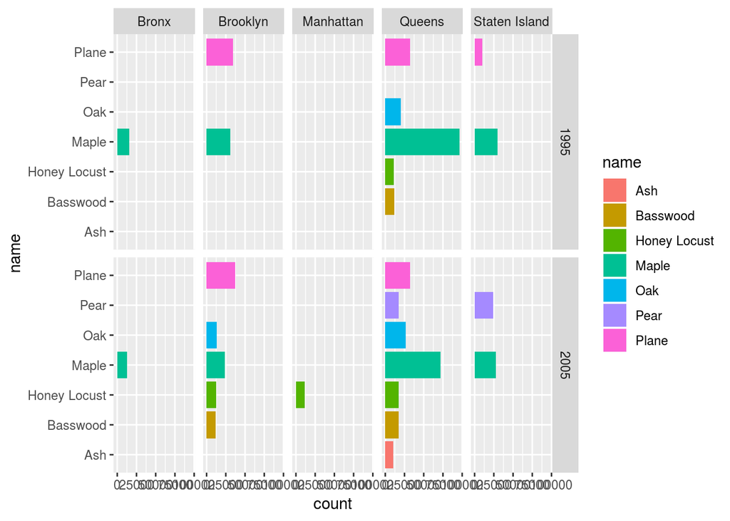

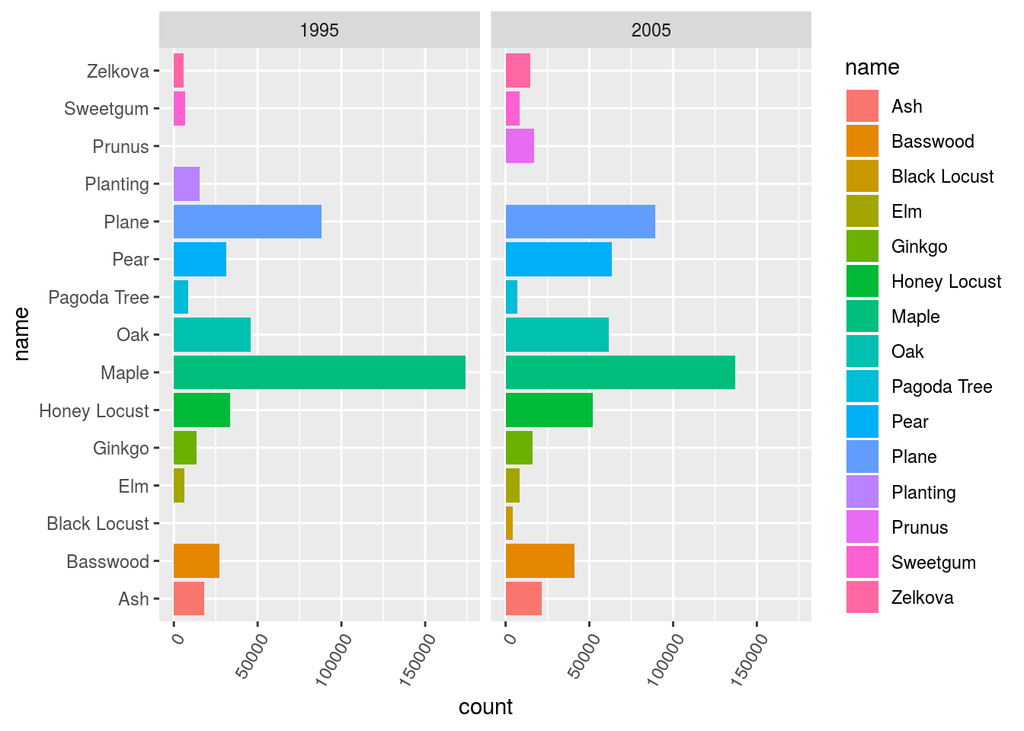

# Tree Density Maps

Here we create low alpha map and a colored map to visualize tree density across NYC and identify the most common tree species

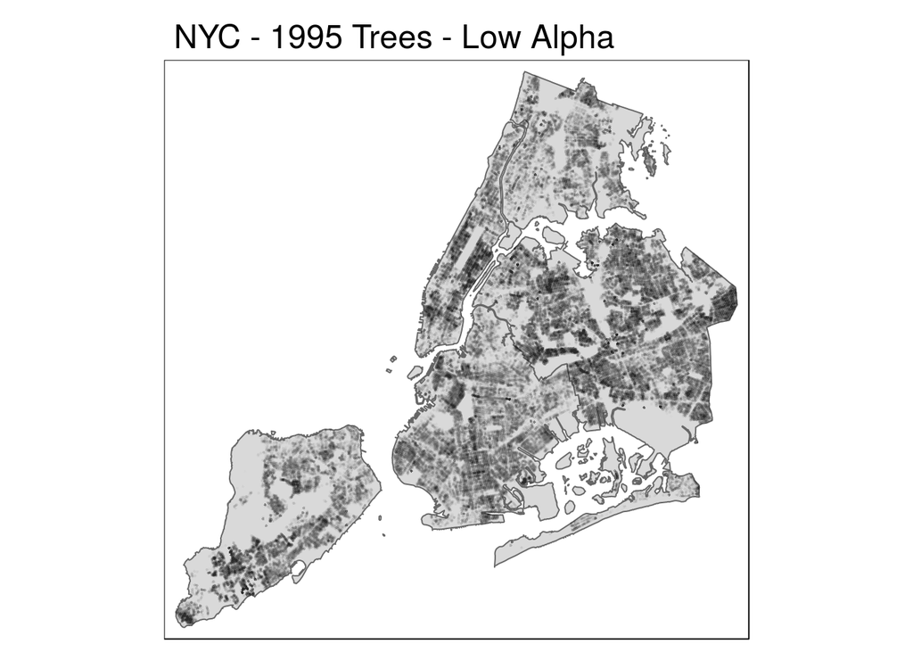

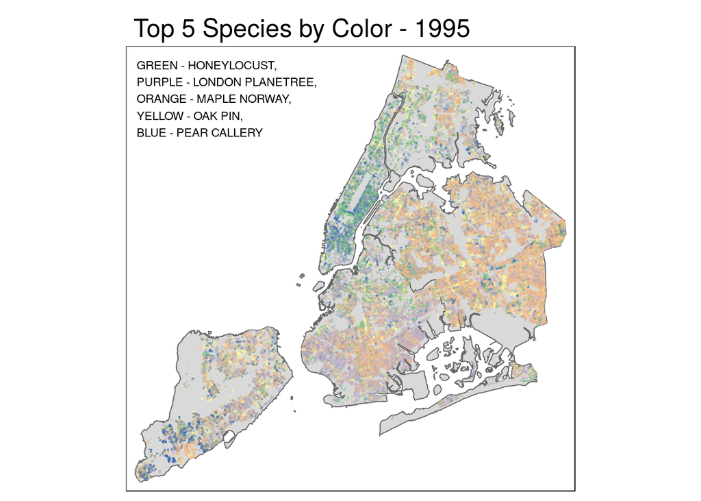

# Air Quality

Here, we analyze the concentration of toxic chemical compounds in NYC in 2005, and 2013

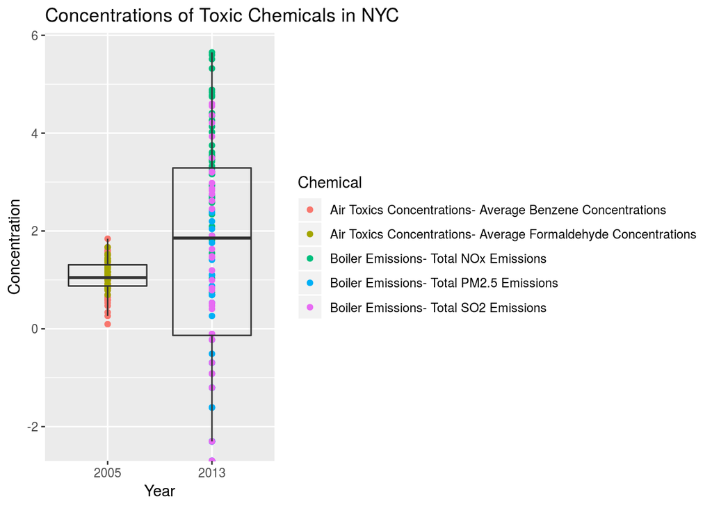

We chose to only focus on the clean 2005 and 2013 data. This way we can two models of tree density vs air quality. The first would be 2005 vs 2005, and 2015 vs 2013 respectively. No air quality data exists for 2015, so we use the closest approximation which is 2013.

## Modeling Tree Density vs. Air Quality

Here we create the datasets required to build our tree density vs air quality model

```
## # A tibble: 42 x 3
##    UHF42   AQI `Tree Density`
##    <chr> <dbl>          <int>
##  1 101    3.05          13098
##  2 102    3             30416
##  3 103    2.95          14538
##  4 104    2.95          31932
##  5 105    3.2           11354
##  6 106    3.3            8144
##  7 107    3.15           8078
##  8 201    3.6           14334
##  9 202    3.45          36688
## 10 203    2.75          26792
## # ... with 32 more rows
```

```
## # A tibble: 1,160,374 x 3
##    UHF42   AQI health
##    <chr> <dbl> <chr>
##  1 101    3.05 Good
##  2 101    3.05 Good
##  3 101    3.05 Bad
##  4 101    3.05 Good
##  5 101    3.05 Good
##  6 101    3.05 Good
##  7 101    3.05 Good
##  8 101    3.05 Good
##  9 101    3.05 Good
## 10 101    3.05 Good
## # ... with 1,160,364 more rows
```

```
## # A tibble: 42 x 3
##    UHF42   AQI `Tree Density`
##    <chr> <dbl>          <int>
##  1 101   20.7           16878
##  2 102   12.1           48339
##  3 103   32.8           32250
##  4 104    9.93          68556
##  5 105   27.1           31458
##  6 106   33.4           29565
##  7 107   13.5           28563
##  8 201    6.47          23541
##  9 202   11.0           61254
## 10 203   10.9           59919
## # ... with 32 more rows
```

```
## # A tibble: 1,935,705 x 3
##    UHF42   AQI health
##    <chr> <dbl> <chr>
##  1 101    20.7 Good
##  2 101    20.7 Good
##  3 101    20.7 Good
##  4 101    20.7 Good
##  5 101    20.7 Good
##  6 101    20.7 Good
##  7 101    20.7 Good
##  8 101    20.7 Good
##  9 101    20.7 Good
## 10 101    20.7 Good
## # ... with 1,935,695 more rows
```

## Models

To explore the relationship between Tree density and Air quality, we make two linear models, one for each of 2005 and 2015

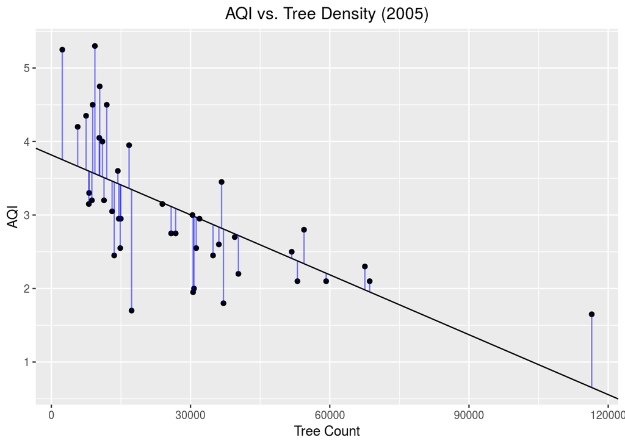

```
## # A tibble: 1 x 3
##   Year  Intercept      Slope
##   <chr>     <dbl>      <dbl>
## 1 2005       3.82 -0.0000272
```

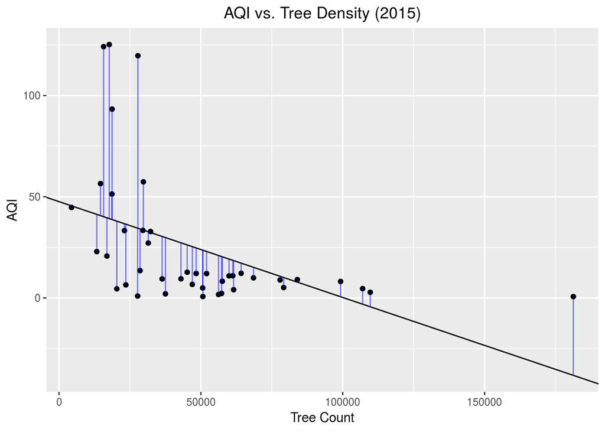

```
## # A tibble: 1 x 3
##   Year  Intercept     Slope
##   <chr>     <dbl>     <dbl>
## 1 2015       47.6 -0.000473
```

Note that each point on the graph represents a UHF42 neighborhood. Furthermore, AQI describes the concentration of chemicals in the air. This means a lower AQI is more desireable. As we expected, as the tree count increases, the average chemical concentration in the area decreases.

## Logistic Models

After we labeled the tree entires as “healthy” vs. “unhealthy”, we apply a logistic model to predict the probability of a tree being healthy given the AQI of the neighborhood it falls in

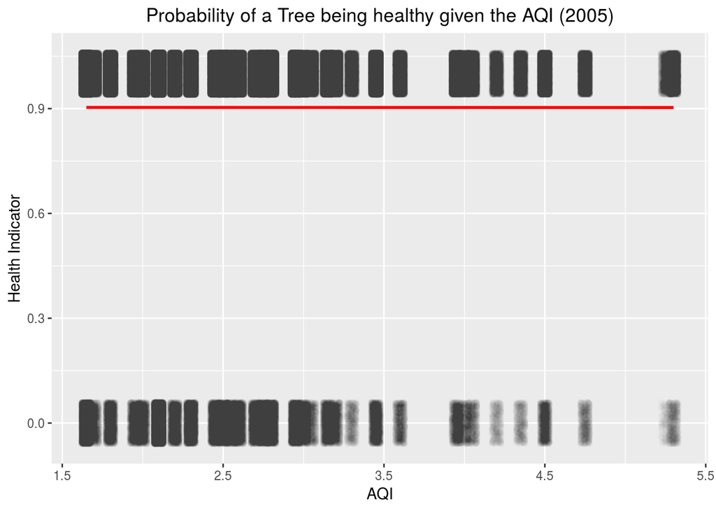

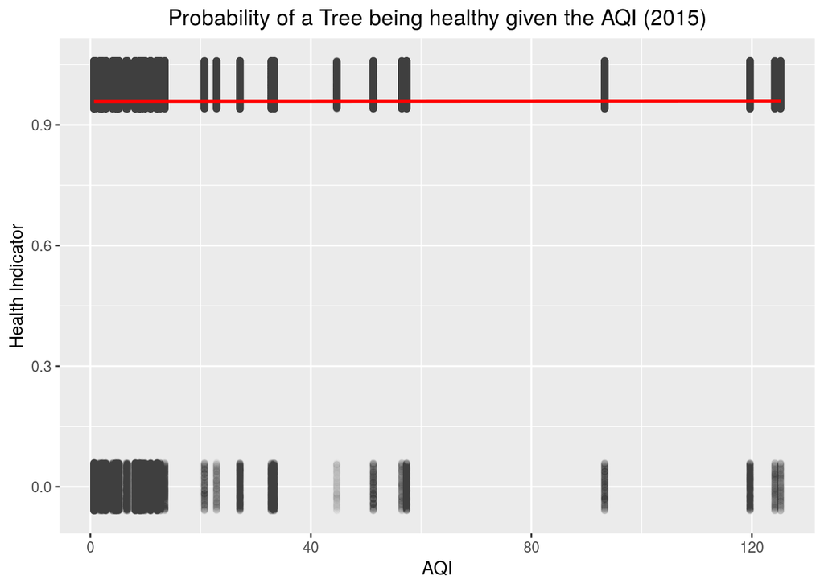

As you can see, in both cases, the regression was a horizontal line. That is, the probability of a tree being healthy is actually independent of the air quality of the neighboorhood it lies in.

# Discussion

There are a few things about our analysis worth noting. Notice how the maps did not have any trees where central park lies. This is obviously inconsistent, as it should have one of the highest tree densities in NYC. This stems from the fact that the data was collected in relation to street positions (as detailed in our presentation), and thus there will be no tree entries for locations not on a street. An interesting find, which limits the overall scope of the dataset but still provides significant information to compare street tree trends across New York City.

Furthermore, our Air Quality analysis was very limited due to the nature of the data. It was very inconsitant in the sense that certain chemicals only appeared in certain years. That is each year category has a different set of listings. We searched all over for another NYC air quality dataset but could not find one. Therefore, we could not come up with an accurate Air Quality Index (AQI) to describe the districts. Instead, we calculated AQI by averaging the concentrations of all the chemcials that appeared for that certain year. This, way, we at least have an index that is relatively meaningful (relative to the indices of other areas), which we can use to model Air Quality vs. Tree Density.

# Interactive App

We built an interactive app that plots the heat maps as shown in our presentation by allowing the user to select the borough and year, and then returning a map of the tree density. The app also includes a second tab of the most common species from that selected borough and year. Our interactive app when ran locally includes all of the data from 1995, 2005, and 2015, but we were only able to include the 2015 data when we hosted the app online, due to space limitations. The 2015 app can be accessed at: https://zthalv.shinyapps.io/NYTrees/

(The app takes some time to load the maps so it may appear blank at first)

# Conclusion

Looking at the low alpha map, we can see that the highest tree density occurs arround central park in Manhatten. This is to be expected since Central Park is one of the largest parks in the coutry, the density would have only been amplified if the tree data for the park was included. The next highest density seems to appear near North-East Queens.

When it comes to the models, despite the inconsistent air quality data, we still observed a relationship that confirmed our suspicion. In both the 2005 and 2015 models, as the tree count increased, the average chemical concentration in the air (AQI) decreased. Furthermore, upon fitting a logistic model of the trees’ health indicator and AQI, we found that the probability of a tree being healthy is actually independent of its neighborhood’s average chemical concentration.